# Week6: Analysis of longitudinal data

Load the packages:

```r
library(dplyr)
library(tidyr)

library(ggplot2)
library(gridExtra)
library(lme4)
```

# Analysis of longitudinal data

## Graphical Displays and Summary Measure Approach

If i got it right, in the first part we are supposed to produce similar plot like in chapter 8 of the book Multivariate Analysis for the Behavioral Sciences, 2nd Edition, but with rats data.

Read the data:

```r
rm(list=ls())

# linkToData <- "data/rats.csv"
linkToData <- "https://raw.githubusercontent.com/RaimoHaikari/IODS-project/master/data/rats.csv"
rats <- read.csv(linkToData, stringsAsFactors = T)

# convert ID and Group to factor values
rats$ID <- factor(rats$ID)
rats$Group <- factor(rats$Group)
```

Check that data looks like it is supposed to.

```
## Observations: 176
## Variables: 5
## $ ID     <fct> 1, 2, 3, 4, 5, 6, 7, 8, 9, 10, 11, 12, 13, 14, 15, 16, ...
## $ Group  <fct> 1, 1, 1, 1, 1, 1, 1, 1, 2, 2, 2, 2, 3, 3, 3, 3, 1, 1, 1...
## $ WD     <fct> WD1, WD1, WD1, WD1, WD1, WD1, WD1, WD1, WD1, WD1, WD1, ...
## $ Weight <int> 240, 225, 245, 260, 255, 260, 275, 245, 410, 405, 445, ...
## $ Time   <int> 1, 1, 1, 1, 1, 1, 1, 1, 1, 1, 1, 1, 1, 1, 1, 1, 8, 8, 8...
```

And as stated in wrangling part: rats are divited into 3 died groubs - and there are different amount of rats in those gropbs.

```
## # A tibble: 3 x 2
##   Group     n
##   <fct> <int>
## 1 1         8
## 2 2         4
## 3 3         4
```

Plot weight values for all 16 rats, differentiating between three diet groubs.

- Because there are 12 different linetypes and 16 rats, we have to recycle linetypes

And what we see is:

- rising trend in each group
- there seems to be outlier in group 2
- tracking phenomeon that is order or mouse weights tends to stay same througout time

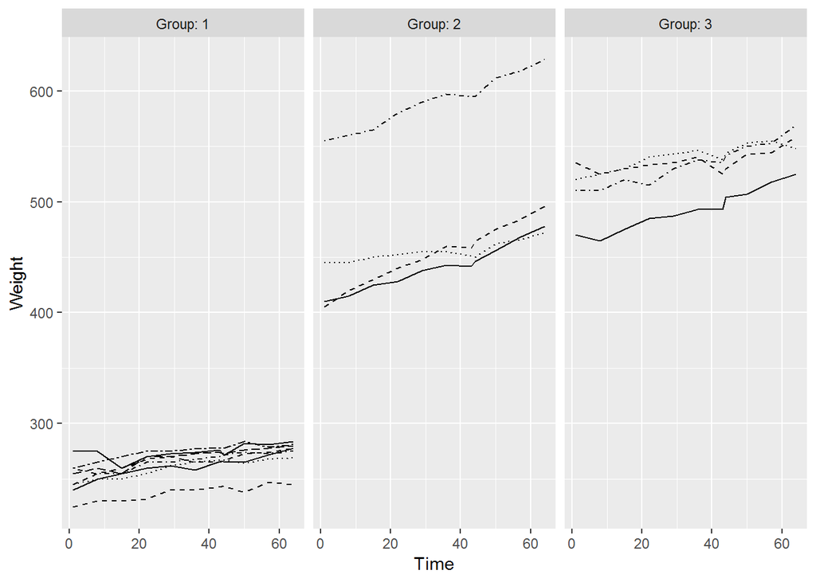

```r
rats %>%
  ggplot(., aes(x = Time)) +
  geom_line(aes(y = Weight, linetype = ID)) +
  scale_linetype_manual(values = c(1:8, 1:4, 1:4)) +
  facet_grid(. ~ Group, labeller = label_both) +
  theme(legend.position = "none")
```

Same plot with standardized values:

- i scale each group separately
- i not sure if tracking is more visible in this version
- lines are more horizontal, easier to observe

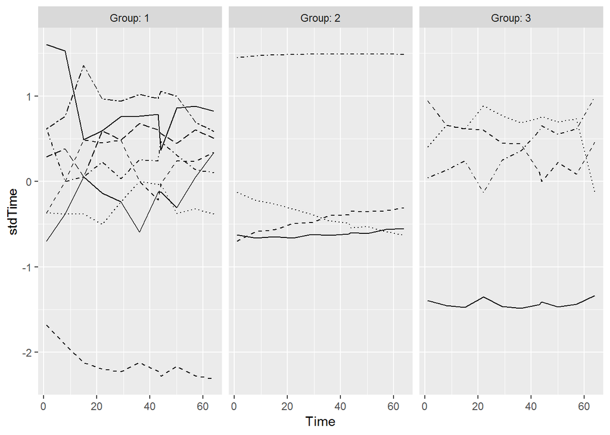

```r
rats %>%
  group_by(Time, Group) %>%
  mutate(stdTime = scale(Weight)) %>%
  ggplot(., aes(x = Time)) +
  geom_line(aes(y = stdTime, linetype = ID)) +
  scale_linetype_manual(values = c(1:8, 1:4, 1:4)) +
  facet_grid(. ~ Group, labeller = label_both) +
  theme(legend.position = "none")
```

Summaries of groups:

- if we shift groups 2 and 3 “a bit” it is easier to see, that third groups values are within standard deviation on second group
- group 2 has large standard deviation when compared to two other groups

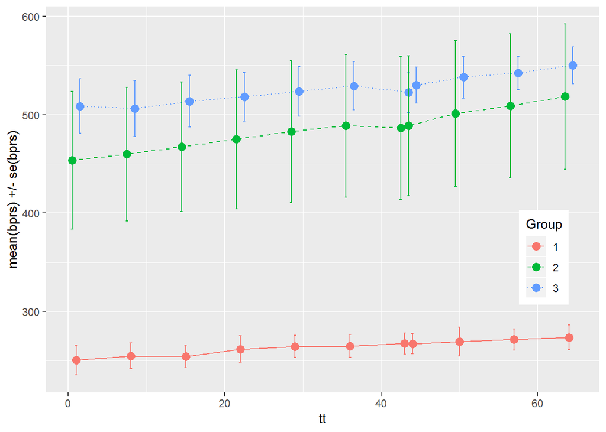

```r
rats %>%
  group_by(Time, Group) %>%
  summarise(mean = mean(Weight), se = sd(Weight)) %>%
  mutate(tt = ifelse(Group == 2, Time - 0.5, ifelse(Group == 3, Time + 0.5, Time))) %>%
  # mutate(tt = ifelse(Group == 2, Time - 0.5, Time)) %>%
  ggplot(., aes(x = tt, linetype = Group, color = Group)) +
  geom_line(aes(y = mean)) +
  scale_linetype_manual(values = c(1,2,3)) +
  geom_point(aes(y = mean), size=3) +
  scale_shape_manual(values = c(1,2,3)) +
  geom_errorbar(aes(ymin=mean-se, ymax=mean+se, linetype="1"), width=0.3) +
  theme(legend.position = c(0.9,0.35)) +
  scale_y_continuous(name = "mean(bprs) +/- se(bprs)")
```

If we plot boxplot, we see that:

- group 1 and 2 have one outlier
- group 3 might have one outlier

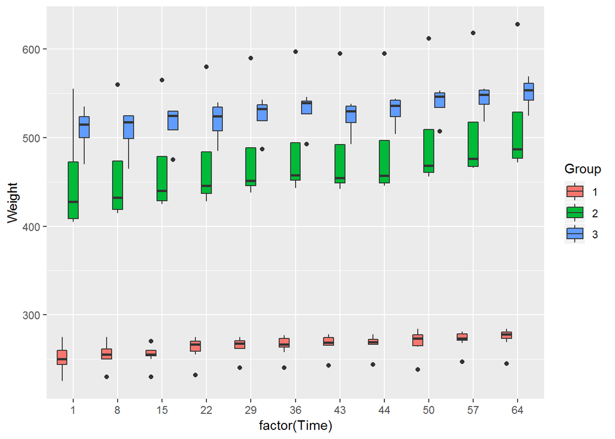

```r
rats %>%
  ggplot(., aes(x = factor(Time))) +
  geom_boxplot(aes(y = Weight, fill=Group))
```

Different kind of boxplot

- outlier don’t show

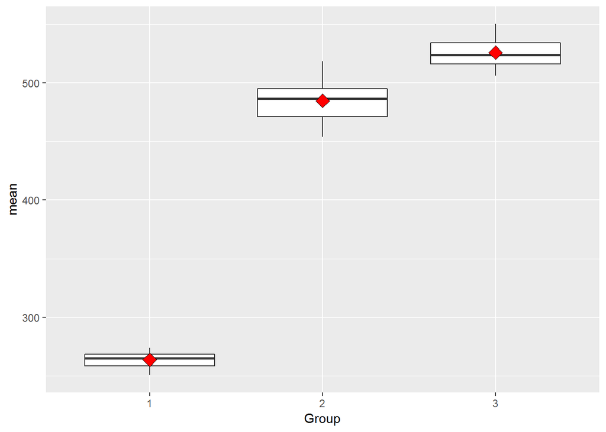

```r
rats %>%
  group_by(Time, Group) %>%
  summarise(mean = mean(Weight), se = sd(Weight)) %>%
  ggplot(., aes(x = Group, y = mean)) +
  geom_boxplot() +
  stat_summary(fun.y = "mean", geom = "point", shape=23, size=4, fill = "red")
```

We can’t do t-test, because there are three groups.

But we can make similar comparison like was done in DataCamp where linear model was build for BPRS data, with exception that now weight is modeled by baseline and groub information.

In order to set baseline of weight, i’ll first have to extract start weights to temporary table and the by using left join feed values back to “long version” of rats data.

```r
A <- rats %>%
  filter(Time == 1)

B <- left_join(rats, A, by = c("ID","Group"))

B$Time.y <- NULL
B$WD.y <- NULL

colnames(B) <- c("ID","Group","WD","Weight","Time","Baseline")

fit <- lm(Weight ~ Baseline + Group, data = B)
```

Summary of the linear model tells:

- Baseline is more important factor in explaining rat weight than diet group
- but witch diet group rat belongs also matters

```r
summary(fit)
```

```
##
## Call:
## lm(formula = Weight ~ Baseline + Group, data = B)
##
## Residuals:
##     Min      1Q  Median      3Q     Max
## -34.273 -12.453   0.832   8.937  56.727
##
## Coefficients:
##             Estimate Std. Error t value Pr(>|t|)
## (Intercept) 30.14886    9.47046   3.183 0.001728 **
## Baseline     0.93194    0.03711  25.114  < 2e-16 ***
## Group2      31.68866    8.14859   3.889 0.000144 ***
## Group3      21.52296   10.06643   2.138 0.033921 *
## ---
## Signif. codes:  0 '***' 0.001 '**' 0.01 '*' 0.05 '.' 0.1 ' ' 1
##
## Residual standard error: 16.77 on 172 degrees of freedom
## Multiple R-squared:  0.9829, Adjusted R-squared:  0.9826
## F-statistic:  3298 on 3 and 172 DF,  p-value: < 2.2e-16
```

And analysis of variance table confirms what was previously stated.

To be honest i don’t understand a heck of what variance table means, but i willing to make a bet that at least two of reviewrs doesn’t know more than i do:-)

```r
anova(fit)
```

```
## Analysis of Variance Table
##
## Response: Weight
##            Df  Sum Sq Mean Sq  F value    Pr(>F)
## Baseline    1 2773370 2773370 9865.281 < 2.2e-16 ***
## Group       2    7989    3994   14.208 1.946e-06 ***
## Residuals 172   48353     281
## ---
## Signif. codes:  0 '***' 0.001 '**' 0.01 '*' 0.05 '.' 0.1 ' ' 1
```

## Linear Mixed Effects Models for Normal Response Variables

In the book (and in DataCamp) different models were presented by using Rats dataset. In this part i’ll try to reproduce examples, but with [BPRS -data](https://raw.githubusercontent.com/KimmoVehkalahti/MABS/master/Examples/data/BPRS.txt). Dataset consist BPRS measurements of 40 patients.

- trial took 9 weeks
- measurements were done once week
- patients are divited to 2 groups.

I have converted original data to “long form” in the data wrangling exercise, so it is ready to use for the purposes of this exercise.

Read the data:

```r
rm(list=ls())

# linkToData <- "data/bprs.csv"
linkToData <- "https://raw.githubusercontent.com/RaimoHaikari/IODS-project/master/data/bprs.csv"
bprs <- read.csv(linkToData, stringsAsFactors = T)

# convert treatment and subject to factor values
bprs$treatment <- factor(bprs$treatment)
bprs$subject <- factor(bprs$subject)
```

### Multiple linear regression

To begin, we will plot the data, indentifying the observations in both groups but ignoring the longitudinal nature of the data. Book separated different groups using numbers, but I’ll confine to colors and shapes.

By looking at the plot, it seems that:

- there might be (small) downward trend
- there might be one or two outliers in group “treatment 2”
- difficult to say wether members of either groups are doing better than other in the other group

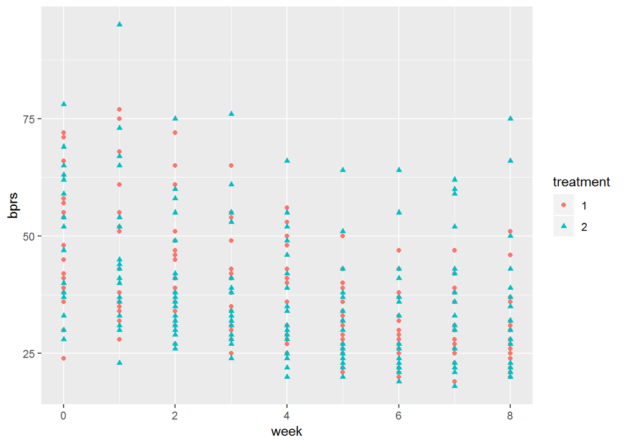

```r
ggplot(bprs, aes(x = week, y = bprs)) +
  geom_point(aes(shape = treatment, color = treatment))
```

Then i’ll setup a multiple linear regression model:

- identifying that the are two treatment groups
- ignoring the longitudinal nature of the measurements
- explicitly dummy-encoding treatment group variable

```r
lmFit <- bprs %>%
  mutate(T1 = ifelse(treatment==1,1,0)) %>%
  lm(bprs ~ week + T1, data = .)
```

In summary:

- residulals don’t look promising; median value should be near zero and distributed evenly, in the model positive spread is much wider
- large p-Value of T1 tells that model doesn’t consider dirrerence between the treatment groups important
- week is considered important

```r
summary(lmFit)
```

```
##
## Call:
## lm(formula = bprs ~ week + T1, data = .)
##
## Residuals:
##     Min      1Q  Median      3Q     Max
## -22.454  -8.965  -3.196   7.002  50.244
##
## Coefficients:
##             Estimate Std. Error t value Pr(>|t|)
## (Intercept)  47.0261     1.3670  34.401   <2e-16 ***
## week         -2.2704     0.2524  -8.995   <2e-16 ***
## T1           -0.5722     1.3034  -0.439    0.661
## ---
## Signif. codes:  0 '***' 0.001 '**' 0.01 '*' 0.05 '.' 0.1 ' ' 1
##
## Residual standard error: 12.37 on 357 degrees of freedom
## Multiple R-squared:  0.1851, Adjusted R-squared:  0.1806
## F-statistic: 40.55 on 2 and 357 DF,  p-value: < 2.2e-16
```

### Linear mixed models

We begin with graphical display of the data that takes into account the longidudinal structure of data by joining together the points belongn to each patient.

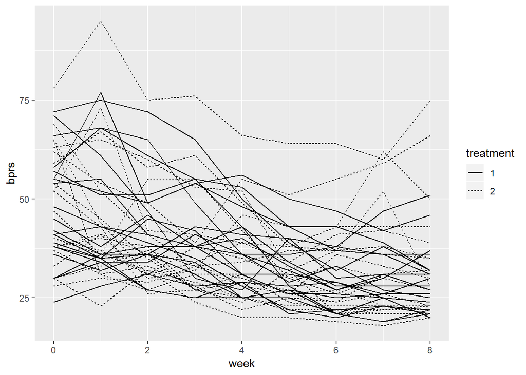

```r
bprs %>%
  mutate(uID = paste(treatment,subject, sep="_")) %>%
  ggplot(., aes(x = week, y = bprs, group = uID)) +
  geom_line(aes(linetype = treatment))
```

If we try to reproduce something exatly like figure 9.2 with BPRS data, graph isn’t particular informative. So i think that plotting disctinct graphs for both treatment gropus works better.

- noqw we can see downward in treatment group 1
- treatment group 2 is bit turbulent, there is also downward trend but with few exeptions

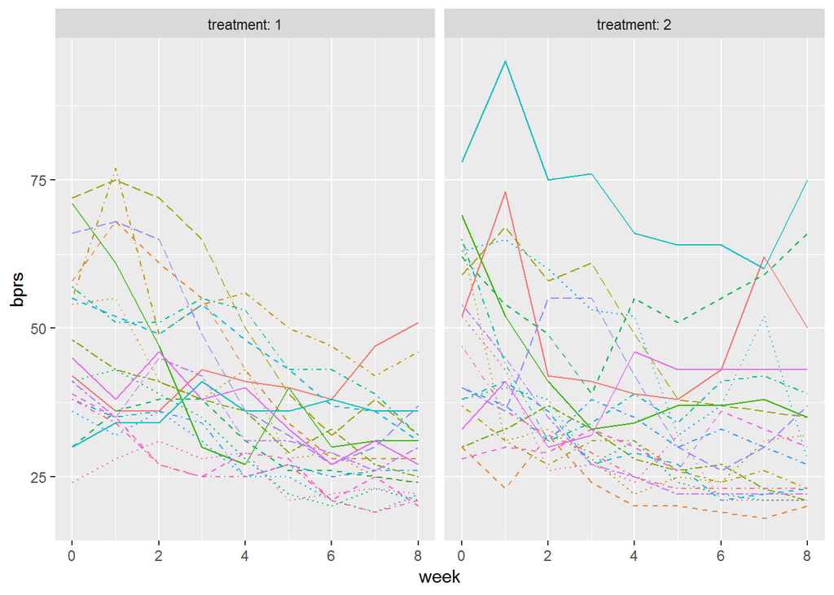

```r
ggplot(bprs, aes(x = week, y = bprs, linetype = subject)) +
  geom_line(aes(color=subject)) +
  scale_linetype_manual(values = c(1:10, 1:10)) +
  theme(legend.position = "none") +
  facet_grid(. ~ treatment, labeller = label_both)
```

### Random intercept model

This model allows the linear regression fit for each patient to differ in intercept from other patiens.

```r
rimFit <- bprs %>%
  mutate(T1 = ifelse(treatment==1,1,0)) %>%
  lmer(bprs ~ week + T1 + (1 | subject),
       data = .,
       REML = FALSE)
```

Then i’ll try to get something out of summary:

- residuals seem to behave better than in first model
- Std. Error of week has improved. In “standard linear model” it was 0.2524 and now it is 0.2084. This is because model now takes account of within-subject depencies of the bprs measurements
- looking at random effects, variance in subject is smaller than variance in residuals. I would interpret that there is more noise in model than subject related information

The book example demonstrated between-subject effect in **group Std. Errors** between Multiple Linear Regression model and Random intercept models when using Rats-data, but i don’t notice similar effect when using BPRS - data.

```r
summary(rimFit)
```

```
## Linear mixed model fit by maximum likelihood  ['lmerMod']
## Formula: bprs ~ week + T1 + (1 | subject)
##    Data: .
##
##      AIC      BIC   logLik deviance df.resid
##   2748.7   2768.1  -1369.4   2738.7      355
##
## Scaled residuals:
##     Min      1Q  Median      3Q     Max
## -3.0481 -0.6749 -0.1361  0.4813  3.4855
##
## Random effects:
##  Groups   Name        Variance Std.Dev.
##  subject  (Intercept)  47.41    6.885
##  Residual             104.21   10.208
## Number of obs: 360, groups:  subject, 20
##
## Fixed effects:
##             Estimate Std. Error t value
## (Intercept)  47.0261     1.9090  24.634
## week         -2.2704     0.2084 -10.896
## T1           -0.5722     1.0761  -0.532
##
## Correlation of Fixed Effects:
##      (Intr) week
## week -0.437
## T1   -0.282  0.000
```

Let’s plot a graph that shows side by side of both treatment groups measured vs. fitted values.

Hmmm… i might have error in somewhere because fitted values of treatment groups 1 and 2 look identical - or maby it’s because model haven’t got enought information to make distinction, level of T1 value in summary might indicate this.

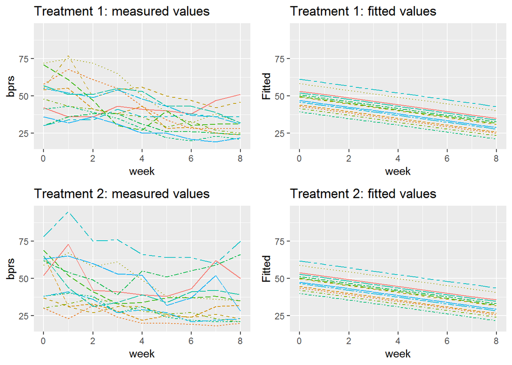

### The random intercept and random slope model

- allows the linear regression fits for each patient to differ in slope
- allows the linear regression fits for each patient to differ in intercept

```r
riNrsFit <-  bprs %>%
    mutate(T1 = ifelse(treatment==1,1,0)) %>%
    lmer(bprs ~ week + T1 + (week | subject),
         data = .,
         REML = FALSE)
```

- fixed effects are more or less the same than in previous model
- in random effects subjects variance has increased; in this model there is more variance in subject values

```r
summary(riNrsFit)
```

```
## Linear mixed model fit by maximum likelihood  ['lmerMod']
## Formula: bprs ~ week + T1 + (week | subject)
##    Data: .
##
##      AIC      BIC   logLik deviance df.resid
##   2745.4   2772.6  -1365.7   2731.4      353
##
## Scaled residuals:
##     Min      1Q  Median      3Q     Max
## -2.8919 -0.6194 -0.0691  0.5531  3.7976
##
## Random effects:
##  Groups   Name        Variance Std.Dev. Corr
##  subject  (Intercept) 64.8202  8.0511
##           week         0.9608  0.9802   -0.51
##  Residual             97.4307  9.8707
## Number of obs: 360, groups:  subject, 20
##
## Fixed effects:
##             Estimate Std. Error t value
## (Intercept)  47.0261     2.1052  22.338
## week         -2.2704     0.2977  -7.626
## T1           -0.5722     1.0405  -0.550
##
## Correlation of Fixed Effects:
##      (Intr) week
## week -0.582
## T1   -0.247  0.000
```

If we compare model using anova **The random intercept and random slope model** is significantly different form model **Random intercept model** at 0.05 level.

```r
anova(rimFit, riNrsFit)
```

```
## Data: .
## Models:
## rimFit: bprs ~ week + T1 + (1 | subject)
## riNrsFit: bprs ~ week + T1 + (week | subject)
##          Df    AIC    BIC  logLik deviance  Chisq Chi Df Pr(>Chisq)
## rimFit    5 2748.7 2768.1 -1369.4   2738.7
## riNrsFit  7 2745.4 2772.6 -1365.7   2731.4 7.2721      2    0.02636 *
## ---
## Signif. codes:  0 '***' 0.001 '**' 0.01 '*' 0.05 '.' 0.1 ' ' 1
```

In the plot:

- fitted graphs still look identical
- in the fitted graphs slopes vary

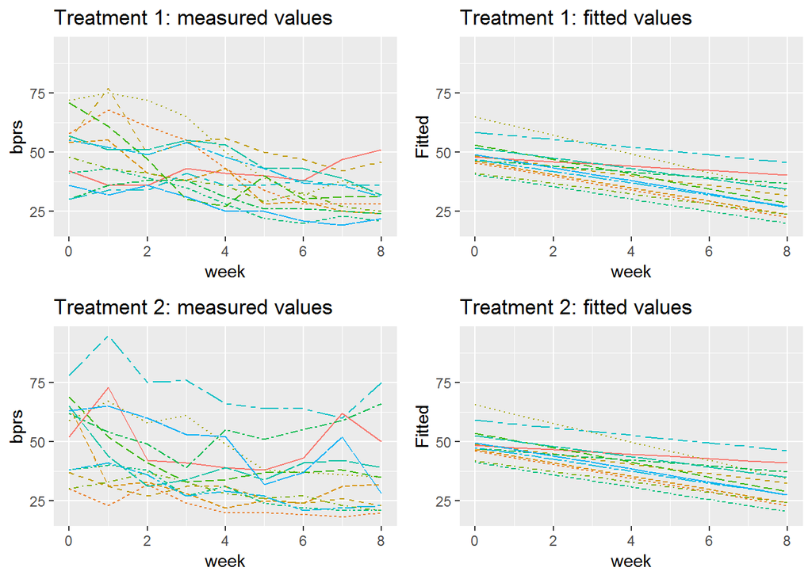

[figure not shown]

### Random Intercept and Random Slope Model with interaction

Finally, we can fit a random intercept and slope model that allows for a **week** x **treatment** interaction

```r
finalModel <- bprs %>%
  mutate(T1 = ifelse(treatment==1,1,0)) %>%
  lmer(bprs ~ week + T1 + (week | subject) + (week * T1),
       data = .,
       REML = FALSE)
```

```r
summary(finalModel)
```

```
## Linear mixed model fit by maximum likelihood  ['lmerMod']
## Formula: bprs ~ week + T1 + (week | subject) + (week * T1)
##    Data: .
##
##      AIC      BIC   logLik deviance df.resid
##   2744.3   2775.4  -1364.1   2728.3      352
##
## Scaled residuals:
##     Min      1Q  Median      3Q     Max
## -3.0512 -0.6271 -0.0767  0.5288  3.9260
##
## Random effects:
##  Groups   Name        Variance Std.Dev. Corr
##  subject  (Intercept) 65.0016  8.0624
##           week         0.9688  0.9843   -0.51
##  Residual             96.4699  9.8219
## Number of obs: 360, groups:  subject, 20
##
## Fixed effects:
##             Estimate Std. Error t value
## (Intercept)  45.5944     2.2522  20.245
## week         -1.9125     0.3589  -5.328
## T1            2.2911     1.9090   1.200
## week:T1      -0.7158     0.4010  -1.785
##
## Correlation of Fixed Effects:
##         (Intr) week   T1
## week    -0.650
## T1      -0.424  0.469
## week:T1  0.356 -0.559 -0.840
```

Judging by anova -test, there doesn’t seem to clear improvement in this model vs. previous model:

```r
anova(riNrsFit,finalModel)
```

```
## Data: .
## Models:
## riNrsFit: bprs ~ week + T1 + (week | subject)
## finalModel: bprs ~ week + T1 + (week | subject) + (week * T1)
##            Df    AIC    BIC  logLik deviance  Chisq Chi Df Pr(>Chisq)
## riNrsFit    7 2745.4 2772.6 -1365.7   2731.4
## finalModel  8 2744.3 2775.4 -1364.1   2728.3 3.1712      1    0.07495 .
## ---
## Signif. codes:  0 '***' 0.001 '**' 0.01 '*' 0.05 '.' 0.1 ' ' 1
```

And plot looks a lot like previous plot:

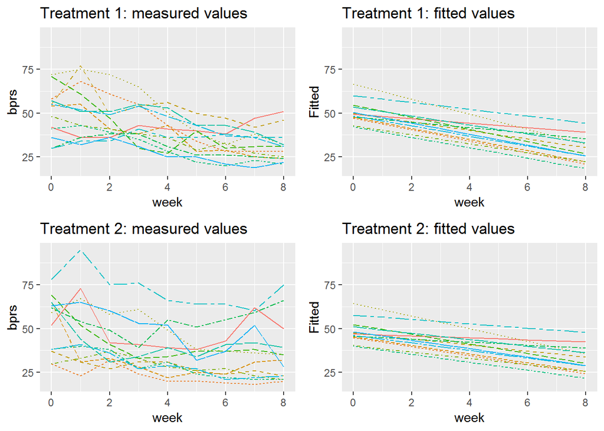

Final conclusion. Any of the model don’t feel good. Maby i missed something or BPRS data doesn’t have enough information.